# Bài tập lý thuyết tuần 6

> Họ và tên: Nguyễn Vạn Phúc Huy  
> MSSV: 23110163  
> Lớp: 23TTH (Sáng thứ 6)

### Bài tập:

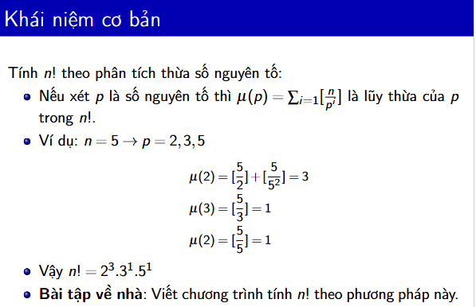

Bài làm

Mã giả cho bài toán phân tích thừa số nguyên tố của n!

[output not shown]

```python
def get_all_primes(n):
    if n < 2:
        return []
    primes = []
    for num in range(2, n + 1):
        is_prime = True
        for divisor in range(2, int(num**0.5) + 1):
            if num % divisor == 0:
                is_prime = False
                break
        if is_prime:
            primes.append(num)
    return primes

def prime_factorization(n):
    if n < 0:
        return None, "Ko nhận số âm"
    if n == 0 or n == 1:
        return 1, {}

    primes = get_all_primes(n)
    prime_factors = {}

    # phi(p)
    for p in primes:
        count = 0
        power = p
        while power <= n:
            count += n // power
            power *= p
        prime_factors[p] = count

    # n!
    result = 1
    for p, count in prime_factors.items():
        result *= (p ** count)

    return result, prime_factors

n = 5
result, factors = prime_factorization(n)

print(f"Prime factorization of {n}")
for p, count in factors.items():
    print(f"phi({p}) = {count}")

# print factorization result
factor_str = " * ".join([f"{p}^{c}" for p, c in factors.items()])
print(f"\n{n}! = {factor_str}")
print(f"{n}! = {result}")
```

```
Prime factorization of 5
phi(2) = 3
phi(3) = 1
phi(5) = 1

5! = 2^3 * 3^1 * 5^1
5! = 120
```

Hàm `prime_factorization(n)` tính n! và phân tích thừa số nguyên tố của n! theo định lý Legendre, sau đó in ra kết quả. Hoạt động như sau:

1. Kiểm tra nếu n < 0, trả về lỗi.
2. Nếu n là 0 hoặc 1, trả về 1 và một dict rỗng.
3. Lấy danh sách các số nguyên tố nhỏ hơn hoặc bằng n.
4. Tính số mũ mu(p) cho từng số nguyên tố p bằng cách sử dụng vòng lặp để tính tổng n // p^k.
5. Tính n! bằng cách nhân các thừa số nguyên tố với số mũ tương ứng và trả về kết quả cùng với dict chứa các thừa số nguyên tố và số mũ của chúng.